# PPOL564 | Data Science 1: Foundations

### Project Presentation

### Transnational Analysis of factors that influence Food Insecurity

#### By : Sonali Subbu Rathinam

#### NetID : ss4608

#### Date : 01/12/2021

### Problem Statement and Background:

Despite *zero hunger* being a SDG (Sustainable Development Goals) target, moderate and severe food insecurity has increased over the years. Hence, this project aims at analysing the influence of the following factors on food insecurity across countries.

- Arable Land (hectares per person)
- Cereal Yield (kilogram per hectare)
- Logistics Performance Indicator (An indicator of a country's trade and transport related infrastructure)
- Wage and Salaried Workers (% of total employment in a country)
- Climate Change Performance Index
- Poverty (Percent of Population earning below the national poverty line)
- Home Ownership Rate

The **Global Food Insecurity Index** measures food security across most countries of the world since 2012. This is used as the target variable of this project. It's on a scale of 100, hence a higher GFSI index implies lower food insecurity.

The aforementioned factors are the predictor variables used in this project. There are many other factors that influence food insecurity. These factors were chosen as they are some of the main driving factors of food insecurity in most countries.

### Data Collection and Wrangling

Data was obtained using either of the following methods:

- Web-scraping using BeautifulSoup package.
- Web-scraping using pd.read_html() function.
- Using wbdata, to obtain world bank data.

Data wrangling steps included:

- Using country convertor to ensure all country names are in a standard form, and to merge dataframes correctly.
- Merging all the individuals dataframes obtained during data collection, and only retaining rows that had atleast 70% Non NA values.
- Reducing the number of NA values by obtaining data on the same predictor variables from different sources and modifying the dataframe.
- Imputing the remaining missing data using KNN Imputer. However, most of the NA values have the same value after imputing, even after trying different neighbours. Hence, other alternative ways of imputing such Stochastic Regression Imputation or Multivariate Imputation by Chained Equation (MICE) needs to be explored.

The final dataframe obtained includes data from 111 countries across 7 years (2012 - 2018). There are a total of 744 rows.

```python
df_final.sample(3)
```

|  | Country | Year | GFSI_Index | Arable_Land | Cereal_Yield | SalariedEmp | LPI_Score | CCPI | Poverty | HomeOwn_Rate |
| --- | --- | --- | --- | --- | --- | --- | --- | --- | --- | --- |
| 578 | Brazil | 2017 | 67.7 | 0.268301 | 5209.5 | 67.699997 | 2.99 | 1 | 26.50 | 71.114516 |
| 742 | Netherlands | 2018 | 81.0 | 0.059252 | 8317.8 | 83.309998 | 4.02 | 1 | 33.15 | 71.114516 |
| 523 | Pakistan | 2016 | 53.8 | 0.152187 | 3020.7 | 38.650002 | 2.92 | 0 | 33.15 | 71.114516 |

Supervised statistical models will be used on this data to analyse which factors strongly influence and impact the variable of interest, the GFSI index. Supervised learning models for regression will be used as input/predictor and output/target variables are available and labelled The models that will be considered are:

- Linear Regression
- Support Vector Regression
- Decision Trees
- Random Forest

The project also aims at using CNN (Convolutional neural network), and comparing its metrics with that of the aforementioned supervised learning models, if it is possible.

## Results

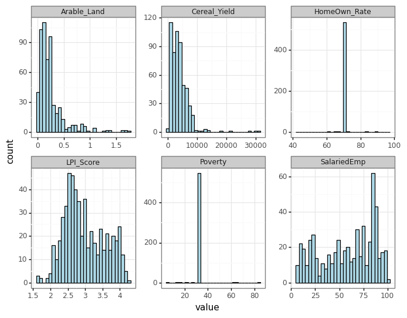

```python
print(v1)
```

From the previous visualisations of the continous variables in the model, it is clear that the imputation for Poverty and Home Ownership Rates have not been very successful. Hence, other forms of imputations and other methods of filling NAs (finding other data sources for these variables) must be done. We also observe a right skew in Arable Land and Cereal Yield predictors. Hence, they will be logged before employing the models.

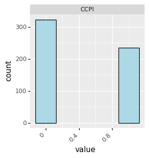

```python
print(v2)
```

From the above visualisation of the categorical variable, it is clear that there are fewer countries who report their Climate Change Performance Indices over the years.

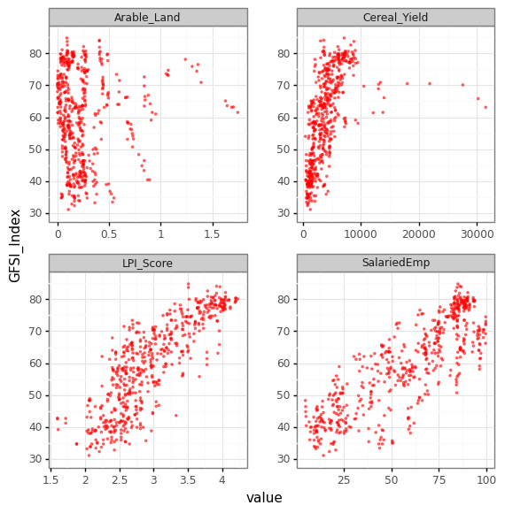

```python
print(v3)
```

The previous visualisations were a representation of how the continous variables relate to the outcome, the GFSI index. We observe a strong positive relation between the LPI Scores and Salaried Employees with the GFSI index. Most countries tend to have similar values of Arable Land and Cereal Yield, but exhibit different values of GFSI index, along with a few outliers having higher values of the predictor variables.

## Lessons Learnt and Plans to Mitigate

- Importance of using country convertor package
- Better understanding of web-scraping and data wrangling (especially merging and column binding)
- Learning to deal with missing data and the different methods of imputation that can be used.